# Water Pump Analysis

```r
set.seed(42)
water <- read.csv("waterTraining.csv")
trainLabels <- read.csv("waterTrainingLabels.csv")
test <- read.csv("waterTest.csv")
```

```r
dim(water)
```

```
[1] 59400    40
```

```r
colnames(water)
```

```
 [1] "id"                    "amount_tsh"            "date_recorded"
 [4] "funder"                "gps_height"            "installer"
 [7] "longitude"             "latitude"              "wpt_name"
[10] "num_private"           "basin"                 "subvillage"
[13] "region"                "region_code"           "district_code"
[16] "lga"                   "ward"                  "population"
[19] "public_meeting"        "recorded_by"           "scheme_management"
[22] "scheme_name"           "permit"                "construction_year"
[25] "extraction_type"       "extraction_type_group" "extraction_type_class"
[28] "management"            "management_group"      "payment"
[31] "payment_type"          "water_quality"         "quality_group"
[34] "quantity"              "quantity_group"        "source"
[37] "source_type"           "source_class"          "waterpoint_type"
[40] "waterpoint_type_group"
```

```r
head(water)
```

|  | id | amount_tsh | date_recorded | funder | gps_height | installer | longitude | latitude | wpt_name | num_private | basin | subvillage | region | region_code | district_code | lga | ward | population | public_meeting | recorded_by | scheme_management | scheme_name | permit | construction_year | extraction_type | extraction_type_group | extraction_type_class | management | management_group | … |
| --- | --- | --- | --- | --- | --- | --- | --- | --- | --- | --- | --- | --- | --- | --- | --- | --- | --- | --- | --- | --- | --- | --- | --- | --- | --- | --- | --- | --- | --- | --- |
| 1 | 69572 | 6000 | 2011-03-14 | Roman | 1390 | Roman | 34.93809 | -9.856322 | none | 0 | Lake Nyasa | Mnyusi B | Iringa | 11 | 5 | Ludewa | Mundindi | 109 | True | GeoData Consultants Ltd | VWC | Roman | False | 1999 | gravity | gravity | gravity | vwc | user-group | … |
| 2 | 8776 | 0 | 2013-03-06 | Grumeti | 1399 | GRUMETI | 34.69877 | -2.147466 | Zahanati | 0 | Lake Victoria | Nyamara | Mara | 20 | 2 | Serengeti | Natta | 280 |  | GeoData Consultants Ltd | Other |  | True | 2010 | gravity | gravity | gravity | wug | user-group | … |
| 3 | 34310 | 25 | 2013-02-25 | Lottery Club | 686 | World vision | 37.46066 | -3.821329 | Kwa Mahundi | 0 | Pangani | Majengo | Manyara | 21 | 4 | Simanjiro | Ngorika | 250 | True | GeoData Consultants Ltd | VWC | Nyumba ya mungu pipe scheme | True | 2009 | gravity | gravity | gravity | vwc | user-group | … |
| 4 | 67743 | 0 | 2013-01-28 | Unicef | 263 | UNICEF | 38.48616 | -11.155298 | Zahanati Ya Nanyumbu | 0 | Ruvuma / Southern Coast | Mahakamani | Mtwara | 90 | 63 | Nanyumbu | Nanyumbu | 58 | True | GeoData Consultants Ltd | VWC |  | True | 1986 | submersible | submersible | submersible | vwc | user-group | … |
| 5 | 19728 | 0 | 2011-07-13 | Action In A | 0 | Artisan | 31.13085 | -1.825359 | Shuleni | 0 | Lake Victoria | Kyanyamisa | Kagera | 18 | 1 | Karagwe | Nyakasimbi | 0 | True | GeoData Consultants Ltd |  |  | True | 0 | gravity | gravity | gravity | other | other | … |
| 6 | 9944 | 20 | 2011-03-13 | Mkinga Distric Coun | 0 | DWE | 39.17280 | -4.765587 | Tajiri | 0 | Pangani | Moa/Mwereme | Tanga | 4 | 8 | Mkinga | Moa | 1 | True | GeoData Consultants Ltd | VWC | Zingibali | True | 2009 | submersible | submersible | submersible | vwc | user-group | … |

We are trying to predict whether a water pipe is functional, non-functional, or functional but needs repair.

```r
unique(trainLabels$status_group)
```

```
[1] functional              non functional          functional needs repair
Levels: functional functional needs repair non functional
```

```r
length(unique(water$installer))  # checking number of unique installers - too many to add all covariates
```

```
[1] 2146
```

```r
                                 # could maybe group them together though
```

```r
#str(water)
which_numeric = sapply(1:ncol(water),
                       function(x) is.numeric(water[,x]) &&
                         all(is.finite(water[,x])))
str(water[, which_numeric][, -1])  # getting rid of id and seeing just numeric columns
```

```
'data.frame':   59400 obs. of  9 variables:
 $ amount_tsh       : num  6000 0 25 0 0 20 0 0 0 0 ...
 $ gps_height       : int  1390 1399 686 263 0 0 0 0 0 0 ...
 $ longitude        : num  34.9 34.7 37.5 38.5 31.1 ...
 $ latitude         : num  -9.86 -2.15 -3.82 -11.16 -1.83 ...
 $ num_private      : int  0 0 0 0 0 0 0 0 0 0 ...
 $ region_code      : int  11 20 21 90 18 4 17 17 14 18 ...
 $ district_code    : int  5 2 4 63 1 8 3 3 6 1 ...
 $ population       : int  109 280 250 58 0 1 0 0 0 0 ...
 $ construction_year: int  1999 2010 2009 1986 0 2009 0 0 0 0 ...
```

```
[1] "amount_tsh"
[1] "gps_height"
[1] "longitude"
[1] "latitude"
[1] "num_private"
[1] "region_code"
[1] "district_code"
[1] "population"
[1] "construction_year"
```

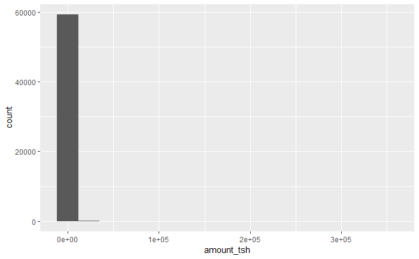

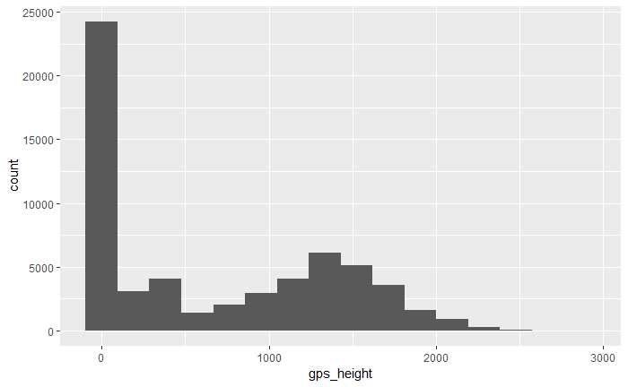

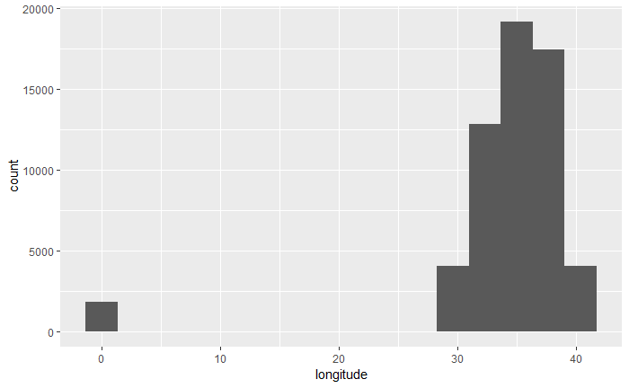

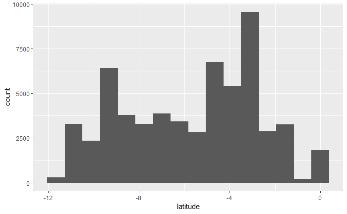

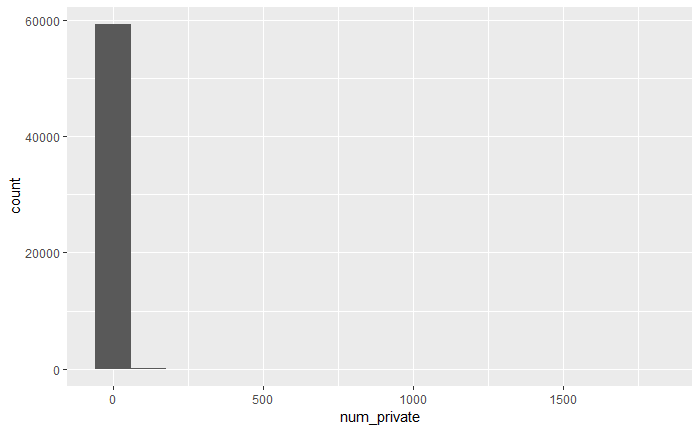

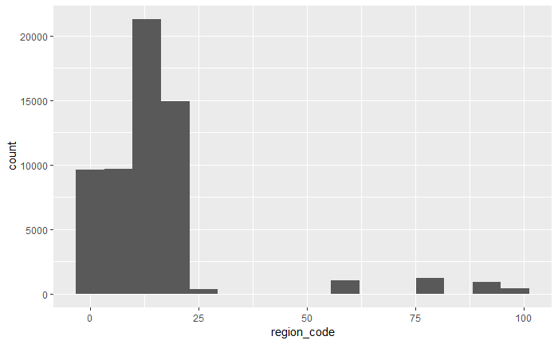

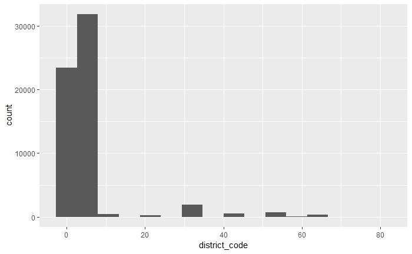

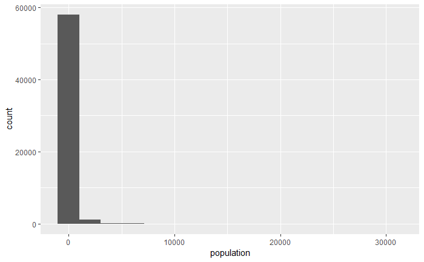

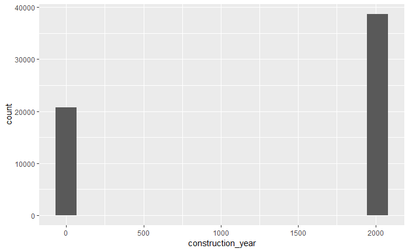

```r
# are these normally distributed?
library(ggplot2)
numCols <- colnames(water[, which_numeric][, -1])
for (col in numCols){
  print(col)
  print(ggplot(water, aes_string(x = col)) + geom_histogram(bins = 1 + 3.322*log10(length(water[,col]))))
}
```

None of them really resemble a normal distribution, and thus, perhaps logistic regression will produce desired results (though there are 3 categories for the response, not binary).

Let’s check again for any missing data

```r
any(apply(water, 2, function(x) any(is.na(x) | is.infinite(x))))  # No N/A or Inf!
```

```
[1] FALSE
```

Seems too good to be true. Maybe encoded as a number, such as zero?

```r
NZero <- data.frame(ColName = c("0", "0"), numZeros = c(0,0))
for (col in colnames(water)) {
  nzero <- sum(water[, col] == 0)
  NZero <- rbind(NZero, data.frame(ColName = c(col), numZeros = c(nzero)))
}
NZero <- NZero[3:nrow(NZero),]
NZero
```

|  | ColName | numZeros |
| --- | --- | --- |
| 3 | id | 1 |
| 4 | amount_tsh | 41639 |
| 5 | date_recorded | 0 |
| 6 | funder | 777 |
| 7 | gps_height | 20438 |
| 8 | installer | 777 |
| 9 | longitude | 1812 |
| 10 | latitude | 0 |
| 11 | wpt_name | 0 |
| 12 | num_private | 58643 |

[output cut: 30 more lines]

```r
dim(water)
```

```
[1] 59400    40
```

```r
head(water[, "amount_tsh"])
```

```
[1] 6000    0   25    0    0   20
```

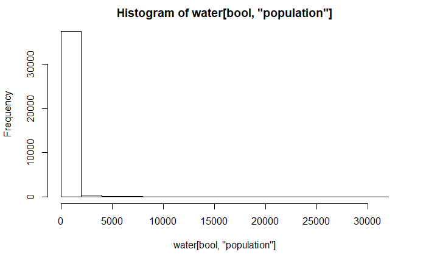

```r
 bool <- water[, "population"] != 0
hist(water[bool, "population"])
```

```r
length(water[bool, "population"])
```

```
[1] 38019
```

```r
nrow(water)
```

```
[1] 59400
```

```r
summary(water[bool, "population"])
```

```
   Min. 1st Qu.  Median    Mean 3rd Qu.    Max.
    1.0    40.0   150.0   281.1   324.0 30500.0
```

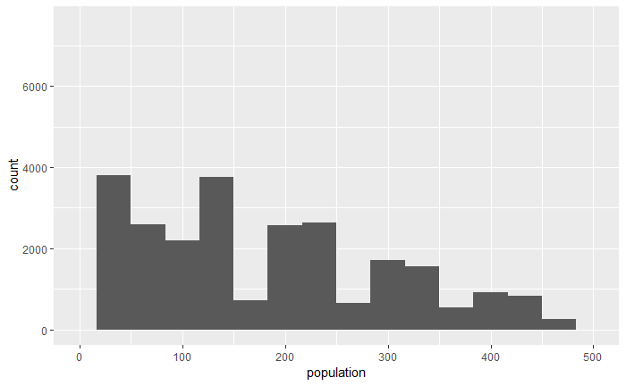

```r
print(ggplot(water[bool,], aes_string(x = "population")) + geom_histogram(bins = 1 + 3.322*log10(length(water[bool,"population"]))) + xlim(0, 500))
```

```r
bool2 <- (water[, "population"] == 0) & (water[, "gps_height"] == 0)
nrow(water[bool2, ])
```

```
[1] 19668
```

```r
length(water[, "population"] == 0)
```

```
[1] 59400
```

```r
length(water[bool, "population"])
```

```
[1] 38019
```

```r
#str(water)
```

We need to get rid of factors with too many levels, as these take up too many degrees of freedom for our predictions, and will help us with variable reduction.

```r
boundary <- 21
count <- 0
indexes <- c()
for (colIndex in 1:(ncol(water))) {
  if (length(levels(water[, colIndex])) > boundary) {
    count <- count + 1
    indexes <- c(indexes, colIndex)
  }
}
count
```

```
[1] 8
```

```r
colnames(water[, indexes])
```

```
[1] "date_recorded" "funder"        "installer"     "wpt_name"
[5] "subvillage"    "lga"           "ward"          "scheme_name"
```

```r
length(levels(water[, "installer"]))  # Thought could be useful but too many
```

```
[1] 2146
```

```r
redWater <- water[, -indexes]
redWater <- subset(redWater, select = -c(recorded_by))   # Factor with only 1 level
```

```r
#str(redWater)
```

There are many categorical predictors, and after looking again at the structure of the dataset we realize that many of them are duplicates of others. By this we mean that some columns are exactly the same, or that some predictors just group some of the labels together, but represent the same measurement. We examined each variable using the table() R command, to see all of the unique label names and counts and compare them with their similar counterparts. In most cases, we chose to keep the predictor with less labels (or the one that grouped together more categories) so that there will be less parameter estimates, saving important degrees of freedom. However, if we thought that the labels should not have been grouped together, and that their responses would vary significantly, we chose to keep the predictor with more variables. The choices are summarized in the table below.

| Removed predictors | Represented By |
| --- | --- |
| extraction_type, extraction_type_group | extraction_type_class |
| management | management_group |
| payment_type | payment |
| water_quality | quality_group |
| quantity_group | quantity |
| source_type, source_class | source |
| waterpoint_type | waterpoint_type_group |

```r
# source_type and source_class is shown in source column, but
#    we need to combine "unknown" category into "other"
redWater <- subset(redWater, select = -c(extraction_type,
                                         extraction_type_group,
                                         management,
                                         payment_type,
                                         water_quality,
                                         quantity_group,
                                         source_type,
                                         source_class,
                                         waterpoint_type))
dim(redWater)
```

```
[1] 59400    22
```

```r
redWater$source[redWater$source == "unknown"] <- "other"
levels(redWater$source) <- droplevels(redWater$source)
dim(redWater)
```

```
[1] 59400    22
```

```r
# write reduced data to file
write.csv(redWater, "ReducedWaterTraining.csv")
```